# Python: sección 1

José Fernando zeea

27/1/2020

```python
import numpy as np
import scipy.stats as st
import matplotlib.pyplot as plt
```

# Estructuras básicas

Entre las estructuras básicas de python están los números, las cadenas de texto, las listas, los conjuntos (sets),las tuplas, los diccionarios, estas estructuras tiene múltiples propositos en diferentes ámbitos de la programación, para el análisis de datos serán más adecuadas otras estructuras como por ejemplo los arreglos de la biblioteca numpy y los dataframes de la biblioteca pandas. Las estructuras más básicas se presentan a continuación:

```python
num = 5
num
```

```
## 5
```

```python
type(num)
```

```
## <class 'int'>
```

```python
num2 = 4.56789
num2
```

```
## 4.56789
```

```python
type(num2)
```

```
## <class 'float'>
```

```python
cadena = 'Juan'
cadena
```

```
## 'Juan'
```

```python
type(cadena)
```

```
## <class 'str'>
```

```python
logico = True
logico
```

```
## True
```

```python
type(logico)
```

```
## <class 'bool'>
```

Dentro de las estructuras más complejos se encuentran las listas, estas admiten diferentes tipos básicos de objetos y son mutables, es decir una vez creadas se pueden modificar:

```python
lista = [2, 7, 8]
lista2 = [2, 'Isabela', True, [1, 2, 3]]
lista
```

```
## [2, 7, 8]
```

```python
lista2
```

```
## [2, 'Isabela', True, [1, 2, 3]]
```

Existe una forma muy ingeniosa de crear secuencias de números en las listas conocida como list comprenhension (muy similar a la notación por comprensión de la teoría de conjuntos que se abordaba en primaria:

```python
[x**2 for x in lista]
```

```
## [4, 49, 64]
```

Para seleccionar elementos basta con indicar las posiciones, en python a diferencia de R y Matlab los subíndices arrancan desde el 0

```python
lista[0:2]
```

```
## [2, 7]
```

Como se mencionó anteriormente las listas son modificables:

```python
lista = [2, 7, 8]
lista
```

```
## [2, 7, 8]
```

```python
lista[2] = 80
lista
```

```
## [2, 7, 80]
```

```python
lista.append(10)
lista
```

```
## [2, 7, 80, 10]
```

Las tuplas tienen funcionalidad muy similar a las listas y se pueden crear con paréntesis o sin parentesis:

```python
# Tuplas
tupla = (2, 7, 8, 8)
tupla2 = 2, 7, 8, 8, 90
tupla
```

```
## (2, 7, 8, 8)
```

```python
tupla2
```

```
## (2, 7, 8, 8, 90)
```

Estos objetos no nos mutables a diferencia de las listas:

```python
# tupla
# tupla[2] = 80 # no permite
# tupla.count(8)
```

Otra estructura muy útil en combinación con la biblioteca pandas (especializada en análisis de datos) es el diccionario, el cual tendrá un rol determinante en hacer operaciones de busqueda muy rápidas y además permitirá crear dataframes de la biblioteca pandas muy rapidamente:

```python
dic = {
  "marca": ['Renault', 'Chevrolet'],
  "modelo": ['Logan', 'Spark'],
  "year": [2018, 2017]
}
dict
```

```
## <class 'dict'>
```

```python
dic["modelo"]
```

```
## ['Logan', 'Spark']
```

```python
type(dic["modelo"])
```

```
## <class 'list'>
```

# Arreglos

Los arreglos son estructuras que interactuan muy bien con pandas y con scipy(útil para hacer cálculos numéricos como por ejemplo las distribuciones de probabilidad y algunas funciones estadísticas)

Un arreglo puede ser unidimensional o bidimensional, observe que los arreglos tienen atributos (por ejemplo itemsize) y métodos (por ejemeplo el método cumsum)

```python
x = np.array([1,2,3, 4, 5])
x
```

```
## array([1, 2, 3, 4, 5])
```

```python
type(x)
```

```
## <class 'numpy.ndarray'>
```

```python
x.itemsize
```

```
## 4
```

```python
x.cumsum()
```

```
## array([ 1,  3,  6, 10, 15], dtype=int32)
```

Otro ejemplo de atributo es la dimensión del arreglo:

```python
x.shape
```

```
## (5,)
```

Los métodos hacen el uso de paréntesis, a diferencia de los atributos que ya vienen empaquetados dentro del objeto, para calculor el método se requiere el uso de una función. Otras estructuras como los pandas dataframes y en general casi cualquier estructura de datos de python poseen atributos y métodos. Los familiarizados con la progrmación orientada a objetos encontrarán esto muy natural (java, C++)

```python
x.mean()
```

```
## 3.0
```

Python dispone de funciones estadísticas y matematicas algunas vienen incorporadas en la biblioteca base (también llamada standard library no requiere instalación), la biblioteca base posee algunos módulos como math. numpy posee también una amplia gama de funciones matemáticas y estadísticas.

```python
import math
math.sin(2)
```

```
## 0.9092974268256817
```

Algunas veces puede ser muy engorros todo el tiempo colocarle el nombre del módulo a las funciones:

```python
from math import sin
sin(2)
```

```
## 0.9092974268256817
```

```python
[sin(i) for i in [1,2,3, 4, 5]]
```

```
## [0.8414709848078965, 0.9092974268256817, 0.1411200080598672, -0.7568024953079282, -0.9589242746631385]
```

La siguiente sentencia no funcionará, ya que se está aplicando la función seno sobre una lista (no sobre un double). Pueden verificar con help(math.sin) que estructura de datos recibe esta función.

```python
#sin([1, 2])
```

Sin embargo en generar el desempeño de las funciones de numpy suele ser mucho mejor, además de que permite realizar las operaciones para varios números dispuestos en un arreglo:

```python
np.sin(np.array([1,2,3, 4, 5, math.pi/2]))
```

```
## array([ 0.84147098,  0.90929743,  0.14112001, -0.7568025 , -0.95892427,
##         1.        ])
```

Las siguientes son algunas funciones matemáticas y estadísticas que trae numpy:

```python
x = np.array([1,2,3, 4, 5])
np.min(x)
```

```
## 1
```

```python
np.sum(x)
```

```
## 15
```

```python
np.mean(x)
```

```
## 3.0
```

```python
np.var(x)
```

```
## 2.0
```

```python
np.std(x)
```

```
## 1.4142135623730951
```

```python
np.max(x)
```

```
## 5
```

Las medidas de localización también se pueden calcular con numpy:

```python
np.quantile(x, 0.25)
```

```
## 2.0
```

```python
np.median(x)
```

```
## 3.0
```

```python
np.quantile(x, 0.75)
```

```
## 4.0
```

Unas medidas muy útiles para conocer la forma de la distribución son la asimetría y la curtosis, estas requeiren el uso de la biblioteca scipy, en particular el módulo stats.

```python
import scipy.stats as st
st.skew([1, 2, 3, 4, 5, 12, 20])
```

```
## 1.1783203188034315
```

La curtosis se calcula de forma similar:

```python
import scipy.stats as st
st.kurtosis([1, 2, 3, 4, 5, 12, 20])
```

```
## -0.05908660412330935
```

## Creación de secuencias y slicing

```python
a = np.arange(1,10)
a
```

```
## array([1, 2, 3, 4, 5, 6, 7, 8, 9])
```

Posteriormente creamos una secuencia del 1 al 31 (sin incluirlo) saltanto de tres en tres:

```python
a = np.arange(1,31, 3, dtype=int)
a
```

```
## array([ 1,  4,  7, 10, 13, 16, 19, 22, 25, 28])
```

Modificamos el objeto anterior:

```python
b = 10 * np.arange(1,31, 3, dtype=int)
b
```

```
## array([ 10,  40,  70, 100, 130, 160, 190, 220, 250, 280])
```

```python
len(b)
```

```
## 10
```

Algunas reglas para realizar slicing (selección de ítems) * a[inicio:fin]: inicio del ítem hasta el paso fin-1 * a[inicio:]: ítems desde el inicio hasta el fin del arreglo * a[:fin]: ítems desde al inicio al paso stop-1 * a[:]: copiar el arreglo completo  
* a[inicio:fin:paso] # desde el inicio a fin-1 saltando el número de pasos especificado. Se puede seleccionar mediante subíndices, para seleccionar posiciones específicas:

```python
b
```

```
## array([ 10,  40,  70, 100, 130, 160, 190, 220, 250, 280])
```

```python
b[[0, 5, 2]]
```

```
## array([ 10, 160,  70])
```

Para seleccionar desde una posición específica de ahí en adelante:

```python
b
```

```
## array([ 10,  40,  70, 100, 130, 160, 190, 220, 250, 280])
```

```python
b[2:]
```

```
## array([ 70, 100, 130, 160, 190, 220, 250, 280])
```

Para seleccionar hasta una posición espécifica (por ejemplo hsta llegar a la posición 3):

```python
b
```

```
## array([ 10,  40,  70, 100, 130, 160, 190, 220, 250, 280])
```

```python
b[:4]
```

```
## array([ 10,  40,  70, 100])
```

Se puede seleccionar entre la posición 3 y la 7

```python
b
```

```
## array([ 10,  40,  70, 100, 130, 160, 190, 220, 250, 280])
```

```python
b[3:8]
```

```
## array([100, 130, 160, 190, 220])
```

Finalmente se puede seleccionar de forma inversa

```python
b
```

```
## array([ 10,  40,  70, 100, 130, 160, 190, 220, 250, 280])
```

```python
b[-2:]
```

```
## array([250, 280])
```

Se puede seleccionar los objetos de manera secuencial, en este caso saltando de tres en tres:

```python
b
```

```
## array([ 10,  40,  70, 100, 130, 160, 190, 220, 250, 280])
```

```python
b[1:11:3]
```

```
## array([ 40, 130, 220])
```

Pueden ocurrir situaciones en donde se quiera eliminar algunos elementos (por ejemplo la posición 3, 5 y 6). Para los conocedores en R esto se realiza colocando un signo menos a las posiciones, en python hay muchas formas de hacerlo pero una sencilla es la siguiente:

```python
b
```

```
## array([ 10,  40,  70, 100, 130, 160, 190, 220, 250, 280])
```

```python
np.delete(b, [3,5,6])
```

```
## array([ 10,  40,  70, 130, 220, 250, 280])
```

Se quiere de eliminar la secuencia del 2 al 8 saltanto de dos en dos:

```python
eliminar = np.arange(2,9, 2, dtype=int)
eliminar
```

```
## array([2, 4, 6, 8])
```

```python
b
```

```
## array([ 10,  40,  70, 100, 130, 160, 190, 220, 250, 280])
```

```python
np.delete(b, eliminar)
```

```
## array([ 10,  40, 100, 160, 220, 280])
```

# Un poco de algrebra líneal

```python
M = np.array([[1,2,3],[4,5,6],[7,8,9]])
V = np.array([[1],[2],[3]])
M
```

```
## array([[1, 2, 3],
##        [4, 5, 6],
##        [7, 8, 9]])
```

```python
V
```

```
## array([[1],
##        [2],
##        [3]])
```

```python
M.shape
```

```
## (3, 3)
```

```python
V.shape
```

```
## (3, 1)
```

```python
v_arreglo = np.array([1, 2, 3])
v_arreglo.shape
```

```
## (3,)
```

```python
2*M + M
```

```
## array([[ 3,  6,  9],
##        [12, 15, 18],
##        [21, 24, 27]])
```

```python
4*V
```

```
## array([[ 4],
##        [ 8],
##        [12]])
```

Se pueden hacer otras operaciones como calcular la transpuesta de una matriz, calcular un determinante, sacar una inversa, la transpuesta de una matriz:

```python
M
```

```
## array([[1, 2, 3],
##        [4, 5, 6],
##        [7, 8, 9]])
```

```python
M.T
```

```
## array([[1, 4, 7],
##        [2, 5, 8],
##        [3, 6, 9]])
```

```python
np.linalg.det(M)
```

```
## -9.51619735392994e-16
```

Esta matriz no tiene inversa.

```python
M = np.array([[1,2,3],[4,50,6],[7,8,90]])
np.linalg.inv(M)
```

```
## array([[ 1.55555556, -0.05450734, -0.04821803],
##        [-0.11111111,  0.02410901,  0.00209644],
##        [-0.11111111,  0.00209644,  0.01467505]])
```

```python
np.linalg.inv(M) * M
```

```
## array([[ 1.55555556, -0.10901468, -0.14465409],
##        [-0.44444444,  1.20545073,  0.01257862],
##        [-0.77777778,  0.01677149,  1.32075472]])
```

# Distribuciones de probabilidad

La función de densidad para la distribución (en R calculado con la función dnorm) se calcula como:

```python
st.norm.pdf([0], loc=0, scale=1)
```

```
## array([0.39894228])
```

```python
st.norm.pdf([0])
```

```
## array([0.39894228])
```

pdf es la sigla de probability distribution function.

matplotlib es un paquete de bajo nivel nivel (el usuario puede realizar cambios al más mínimo detalle en los gráficos) a diferencia de otros paquetes de visualización de datos como seaborn que son gráficos de más alto nivel. Primero partimos en 5000 “pedacitos” el intervalo de -5 a 5 y aplicamos la función anterior:

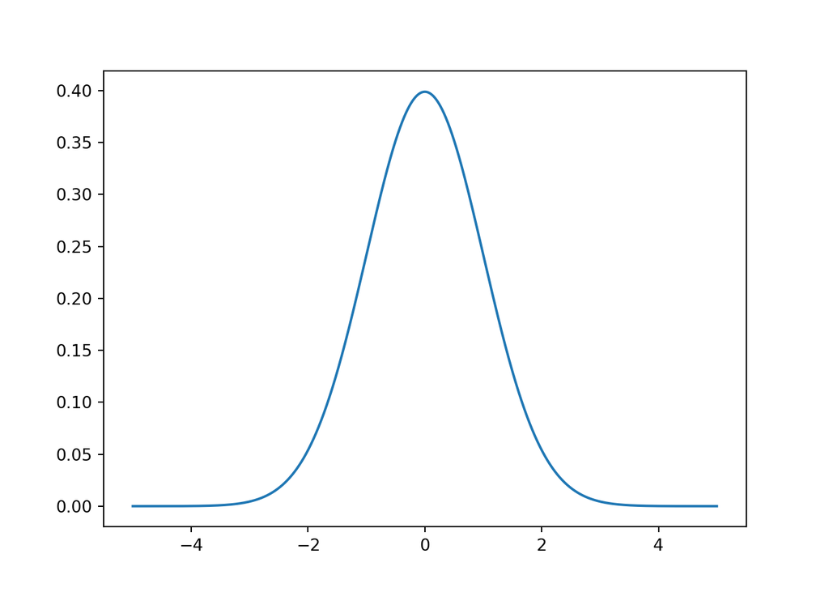

```python
x = np.linspace(-5, 5, 5000)
y = st.norm.pdf(x, loc = 0, scale = 1)
plt.plot(x, y, label='Densidad')
```

Otra función muy útil para trabajar con la distribución normal (en este caso particular, la normal estándar) es la función de distribución acumulada (en R pnorm)

```python
st.norm.cdf([-1.96, -1.64, 0, 1.64, 1.96], loc=0, scale=1)
```

```
## array([0.0249979 , 0.05050258, 0.5       , 0.94949742, 0.9750021 ])
```

La función innversa de la función de distribución acumulada se conoce en python como Percentile point function (inverse cumuladtive distribution, en R se usa la función qnorm)

```python
st.norm.ppf([0.025, 0.05, 0.5, 0.95, 0.975], loc=0, scale=1)
```

```
## array([-1.95996398, -1.64485363,  0.        ,  1.64485363,  1.95996398])
```

Para generar 1000 números aleatorios con distribución normal se puede usar la función rvs:

```python
x_norm = st.norm.rvs(size=1000)
```

```python
np.mean(x)
```

```
## 0.0
```

```python
np.std(x)
```

```
## 2.887328753963894
```

Como colocar semilla:

```python
np.random.seed(seed=12345)
x_norm = st.norm.rvs(size=1000)
np.mean(x_norm)
```

```
## -0.0023507110069417047
```

```python
np.std(x_norm)
```

```
## 0.9794662728546607
```

```python
del(x_norm)
```

```python
np.random.seed(seed=12345)
x_norm = st.norm.rvs(size=1000)
np.mean(x_norm)
```

```
## -0.0023507110069417047
```

```python
np.std(x_norm)
```

```
## 0.9794662728546607
```

## Ejercicio distribución normal

EL promedio de estaturas de las mujeres nacidas en 1996 en Colombia, Promedio: 156.9, Intervalo al 95%: (157.8 - 155.9).

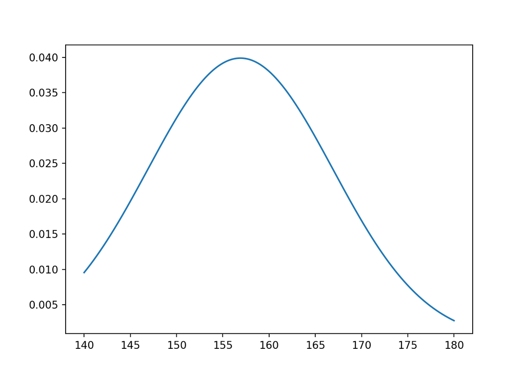

```python
x = np.linspace(140, 180, 5000)
y = st.norm.pdf(x, loc = 156.9, scale = 10)
plt.plot(x, y, label='Densidad')
```

```python
np.random.seed(seed=12345)
estaturas = st.norm.rvs(size=1000000, loc =  156.9, scale = 10)
np.mean(estaturas)
```

```
## 156.91493738066518
```

```python
np.std(estaturas)
```

```
## 9.999526519003652
```

Ejercicio: calcular la probabilidad de que una mujer nacida en el 96 sea mayor a 1,70. Calcule la probabilidad de que esté entre 1,60 y 1,70.